# QTM 151 - Intro to Stats Computing II

Lecture 15 - Aggregating Data

Danilo Freire

danilo.freire@emory.edu

Emory University

23 October, 2024

# Hello, everyone! 👋 Nice to see you all again 😁

# Two quick things before we start 😉

## Some comments on quiz 02

- The quiz has been graded and the grades are in Canvas
- You guys did really well! Congratulations! 🎉
- What do you think about the quiz? Was it too easy? Too hard? Just right?
- If you have any question about the quiz, please let us know
- Please do not forget that the assignment is due today 🤓

## Jupyter Notebooks online 🌐

- New users find it challenging to install Python and Jupyter Notebook on their computers
- So I’ve made a Jupyter Notebook online that you can use to run Python code without installing anything! 🤓
- I’ve used [Pyodide](https://pyodide.org/en/stable/) and [JupyterLite](https://jupyterlite.readthedocs.io/) to run Python code in the browser
- You can access it on the [Jupyter Lite tab on the course website](https://danilofreire.github.io/qtm350/)
- The website is https://danilofreire.github.io/qtm350/jupyter
- It already comes with all packages we need for this class, such as NumPy, Pandas, Matplotlib, and Seaborn
- You can install many other packages too! 📦
- Not all Python packages work, but many do. Install them with

```python
%pip install package-name
```

- You can also use it to run `R` and `JavaScript` code, as well as write `LaTeX` and `Markdown` documents
- Please download your files with the right-click menu before closing the browser!
- Let me know if you find any bugs! 🐞

# Today’s plan 📅

## Aggregating data

### Today we will…

- Learn about different ways to gather dataset characteristics
- Learn how to aggregate data using Pandas using the `.agg()` method
- Combine `.agg()` with `.groupby()` to aggregate data by groups
- Use `.query()` together with those methods to filter and summarise data in one step

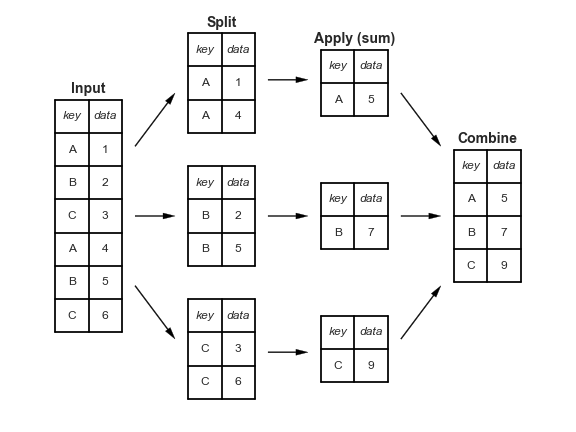

[Split-apply-combine strategy](https://jakevdp.github.io/PythonDataScienceHandbook/03.08-aggregation-and-grouping.html#GroupBy:-Split,-Apply,-Combine)

## Import libraries and load data

- As usual, let’s start by importing the libraries we need

```python
import numpy as np
import pandas as pd
import matplotlib.pyplot as plt
```

- And load the dataset we will use today

```python
results = pd.read_csv("data_raw/results.csv")
```

- These data are part of the [Formula 1 dataset](https://www.kaggle.com/rohanrao/formula-1-world-championship-1950-2020) we used in the past

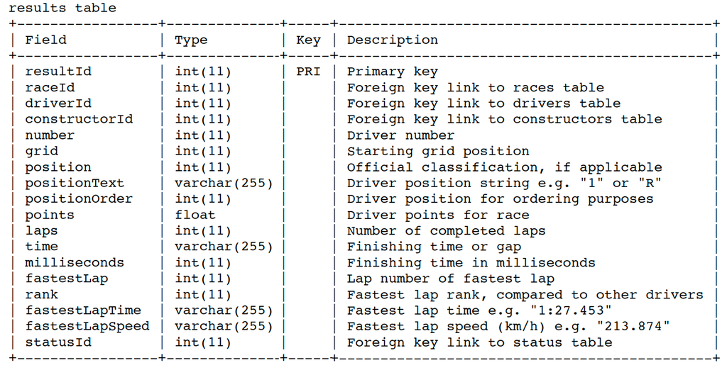

- Main information: `Field`, `Type`, `Key`, and `Description`
- `Field` is the name of the column
- `Type` is the data type of the column
  - integer (`int`)
  - string (`varchar` - “variable character”)
  - float (`float`)
  - The number in parenthesis is the maximum number of characters/digits
- `Key` is the primary key of the table, also know as the identifier
  - It is unique for each row and can be used to join tables (more on that later)
- `Description` is a brief description of the column

## Display the first few rows

```python
results.head()
```

|  | resultId | raceId | driverId | constructorId | number | grid | position | positionText | positionOrder | points | laps | time | milliseconds | fastestLap | rank | fastestLapTime | fastestLapSpeed | statusId |
| --- | --- | --- | --- | --- | --- | --- | --- | --- | --- | --- | --- | --- | --- | --- | --- | --- | --- | --- |
| 0 | 1 | 18 | 1 | 1 | 22 | 1 | 1 | 1 | 1 | 10.0 | 58 | 1:34:50.616 | 5690616 | 39 | 2 | 1:27.452 | 218.300 | 1 |
| 1 | 2 | 18 | 2 | 2 | 3 | 5 | 2 | 2 | 2 | 8.0 | 58 | +5.478 | 5696094 | 41 | 3 | 1:27.739 | 217.586 | 1 |
| 2 | 3 | 18 | 3 | 3 | 7 | 7 | 3 | 3 | 3 | 6.0 | 58 | +8.163 | 5698779 | 41 | 5 | 1:28.090 | 216.719 | 1 |
| 3 | 4 | 18 | 4 | 4 | 5 | 11 | 4 | 4 | 4 | 5.0 | 58 | +17.181 | 5707797 | 58 | 7 | 1:28.603 | 215.464 | 1 |
| 4 | 5 | 18 | 5 | 1 | 23 | 3 | 5 | 5 | 5 | 4.0 | 58 | +18.014 | 5708630 | 43 | 1 | 1:27.418 | 218.385 | 1 |

- See a random sample of the data using `sample`

```python
results.sample(5).sort_values("resultId")
```

|  | resultId | raceId | driverId | constructorId | number | grid | position | positionText | positionOrder | points | laps | time | milliseconds | fastestLap | rank | fastestLapTime | fastestLapSpeed | statusId |
| --- | --- | --- | --- | --- | --- | --- | --- | --- | --- | --- | --- | --- | --- | --- | --- | --- | --- | --- |
| 5224 | 5225 | 260 | 77 | 6 | 28 | 3 | 3 | 3 | 3 | 4.0 | 78 | +1:16.824 | 6672124 | \N | \N | \N | \N | 1 |
| 7979 | 7980 | 358 | 160 | 45 | 18 | 0 | \N | F | 30 | 0.0 | 0 | \N | \N | \N | \N | \N | \N | 97 |
| 10260 | 10261 | 437 | 176 | 21 | 17 | 23 | 9 | 9 | 9 | 0.0 | 71 | \N | \N | \N | \N | \N | \N | 14 |
| 16589 | 16590 | 677 | 321 | 6 | 7 | 15 | \N | R | 19 | 0.0 | 14 | \N | \N | \N | \N | \N | \N | 5 |
| 23454 | 23459 | 973 | 1 | 131 | 44 | 1 | 1 | 1 | 1 | 25.0 | 66 | 1:35:56.497 | 5756497 | 64 | 1 | 1:23.593 | 200.471 | 1 |

## Get the column names and types

- We can get the column names and types using `dtypes`

```python
results.dtypes
```

```
resultId             int64
raceId               int64
driverId             int64
constructorId        int64
number              object
grid                 int64
position            object
positionText        object
positionOrder        int64
points             float64
laps                 int64
time                object
milliseconds        object
fastestLap          object
rank                object
fastestLapTime      object
fastestLapSpeed     object
statusId             int64
dtype: object
```

- We can also get the column names using `columns`

```python
results.columns
```

```
Index(['resultId', 'raceId', 'driverId', 'constructorId', 'number', 'grid',
       'position', 'positionText', 'positionOrder', 'points', 'laps', 'time',
       'milliseconds', 'fastestLap', 'rank', 'fastestLapTime',
       'fastestLapSpeed', 'statusId'],
      dtype='object')
```

## Try it yourself! 🤓

- How many rows does the dataset have?
- How many unique values are there for the columns:
  - `resultId`?
  - `raceId`?
  - `driverId`?
- Hint: Use the [`len()`](https://docs.python.org/3/library/functions.html#len) and the [`pd.nunique()`](https://pandas.pydata.org/pandas-docs/stable/reference/api/pandas.Series.nunique.html) functions (click on their names to see the documentation)
- Appendix 01

# Group by and aggregate 📊

## Multi-line code

- You can split your code into multiple lines to make it easier to read
- You just need to wrap the code in parentheses `()`

```python
descriptives_multiline = (results["points"]
                          .describe())
descriptives_multiline
```

```
count    25840.000000
mean         1.877053
std          4.169849
min          0.000000
25%          0.000000
50%          0.000000
75%          2.000000
max         50.000000
Name: points, dtype: float64
```

- This is the same as writing

```python
descriptives_singleline = results["points"].describe()
descriptives_singleline
```

```
count    25840.000000
mean         1.877053
std          4.169849
min          0.000000
25%          0.000000
50%          0.000000
75%          2.000000
max         50.000000
Name: points, dtype: float64
```

## Aggregate data using `.agg()`

- The `.agg()` subfunction computes aggregate statistics
- The syntax is (`column_name`, `function_name`)
- The first argument is the column name
- The second argument is the function_name
- The command works with single quotations ‘…’ or double “…”

```python
# The functions in quotes are pandas functions.  len is not in quotes because it is a Python function
# If you were to use 'len' (a string), pandas would look for a method named len in the DataFrame,
# which does not exist.
results_agg = results.agg(mean_points = ('points','mean'),
                          sd_points =   ('points','std'),
                          min_points =  ('points','min'),
                          max_points =  ('points','max'),
                          count_obs   = ('points', len))

display(results_agg.round(2)) # round to 2 decimal places
```

|  | points |
| --- | --- |
| mean_points | 1.88 |
| sd_points | 4.17 |
| min_points | 0.00 |
| max_points | 50.00 |
| count_obs | 25840.00 |

## Group and aggregate data using `.groupby()`

- The `.groupby()` method groups the data by a column
- The `.agg()` method can be used to aggregate the data by group
- The syntax is `df.groupby('column_name').agg(...)`
- Let’s see one example

```python
drivers_agg = (results.groupby("driverId")
                      .agg(mean_points = ('points','mean'),
                           sd_points =   ('points','std'),
                           min_points =  ('points','min'),
                           max_points =  ('points','max'),
                           count_obs   = ('points',len)))
```

```python
drivers_agg
```

| driverId | mean_points | sd_points | min_points | max_points | count_obs |
| --- | --- | --- | --- | --- | --- |
| 1 | 14.182258 | 9.224098 | 0.0 | 50.0 | 310 |
| 2 | 1.407609 | 2.372923 | 0.0 | 15.0 | 184 |
| 3 | 7.740291 | 8.672456 | 0.0 | 25.0 | 206 |
| 4 | 5.756983 | 6.330721 | 0.0 | 25.0 | 358 |
| 5 | 0.937500 | 1.969503 | 0.0 | 10.0 | 112 |
| ... | ... | ... | ... | ... | ... |
| 852 | 1.000000 | 2.477808 | 0.0 | 12.0 | 44 |
| 853 | 0.000000 | 0.000000 | 0.0 | 0.0 | 22 |
| 854 | 0.272727 | 1.335798 | 0.0 | 8.0 | 44 |
| 855 | 0.272727 | 0.882735 | 0.0 | 4.0 | 22 |
| 856 | 2.000000 | NaN | 2.0 | 2.0 | 1 |

855 rows × 5 columns

## Group and aggregate data using `.groupby()`

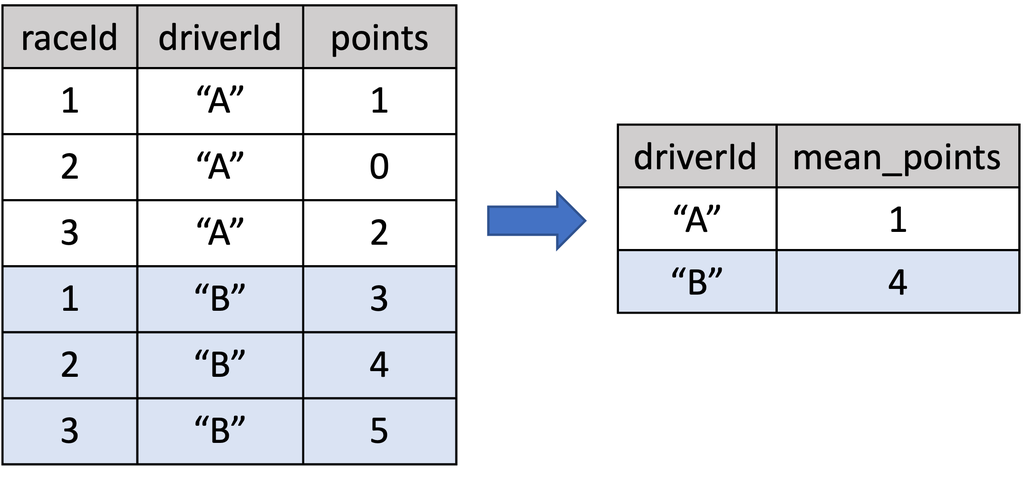

- [Split-apply-combine strategy again](https://jakevdp.github.io/PythonDataScienceHandbook/03.08-aggregation-and-grouping.html#GroupBy:-Split,-Apply,-Combine)
- Split: Split the dataset into groups, here by `driverId`
- Apply: Apply a function to each group, here the mean, standard deviation, minimum, maximum, and count of `points`
- Combine: Combine the results into a single data frame
- The result is a data frame with the statistics for each driver

## Group and aggregate data using `.groupby()` - multiple groups

- The syntax we used before works for one group, but it is easy to extend it to multiple groups
- You can pass a list of columns to the `.groupby()` method
- `df.groupby(['column1', 'column2']).agg(...)`
- `constructorId` is the team identifier

```python
teamrace_agg = (results.groupby(["raceId","constructorId"])
                       .agg(mean_points = ('points','mean'),
                            sd_points =   ('points','std'),
                            min_points =  ('points','min'),
                            max_points =  ('points','max'),
                            count_obs   = ('points',len)))
```

```python
teamrace_agg.round(2)
```

| raceId | constructorId | mean_points | sd_points | min_points | max_points | count_obs |
| --- | --- | --- | --- | --- | --- | --- |
| 1 | 1 | 0.0 | 0.00 | 0.0 | 0.0 | 2 |
|  | 2 | 0.0 | 0.00 | 0.0 | 0.0 | 2 |
|  | 3 | 1.5 | 2.12 | 0.0 | 3.0 | 2 |
|  | 4 | 2.0 | 2.83 | 0.0 | 4.0 | 2 |
|  | 5 | 1.5 | 0.71 | 1.0 | 2.0 | 2 |
| ... | ... | ... | ... | ... | ... | ... |
| 1096 | 117 | 2.5 | 2.12 | 1.0 | 4.0 | 2 |
|  | 131 | 5.0 | 7.07 | 0.0 | 10.0 | 2 |
|  | 210 | 0.0 | 0.00 | 0.0 | 0.0 | 2 |
|  | 213 | 0.0 | 0.00 | 0.0 | 0.0 | 2 |
|  | 214 | 3.0 | 4.24 | 0.0 | 6.0 | 2 |

12568 rows × 5 columns

# Filtering + Grouping + Aggregating 🤓

## Filtering data using `.query()`

- The `.query()` method filters the data, as you know well by now
- We can combine `.query()` with `.groupby()` and `.agg()` to filter, group, and aggregate data in one step

```python
teamrace_agg = (results.query("raceId >= 500")
                       .groupby(["raceId","constructorId"])
                        .agg(mean_points = ('points','mean'),
                             sd_points =   ('points','std'),
                             min_points =  ('points','min'),
                             max_points =  ('points','max'),
                             count_obs   = ('points',len)))
```

```python
teamrace_agg.round(2)
```

| raceId | constructorId | mean_points | sd_points | min_points | max_points | count_obs |
| --- | --- | --- | --- | --- | --- | --- |
| 500 | 1 | 0.0 | 0.00 | 0.0 | 0.0 | 2 |
|  | 3 | 1.0 | 1.41 | 0.0 | 2.0 | 2 |
|  | 4 | 4.5 | 6.36 | 0.0 | 9.0 | 2 |
|  | 6 | 0.0 | 0.00 | 0.0 | 0.0 | 2 |
|  | 21 | 0.5 | 0.71 | 0.0 | 1.0 | 2 |
| ... | ... | ... | ... | ... | ... | ... |
| 1096 | 117 | 2.5 | 2.12 | 1.0 | 4.0 | 2 |
|  | 131 | 5.0 | 7.07 | 0.0 | 10.0 | 2 |
|  | 210 | 0.0 | 0.00 | 0.0 | 0.0 | 2 |
|  | 213 | 0.0 | 0.00 | 0.0 | 0.0 | 2 |
|  | 214 | 3.0 | 4.24 | 0.0 | 6.0 | 2 |

6055 rows × 5 columns

## Try it yourself! 🤓

- Create a new dataset by chaining groups by `constructorId` (the team) then compute the average number of `points`
- Add a chain `.sort_values(...,ascending = False)` to sort by team points in descending order
- Appendix 02

## Different functions for different columns

- You can use different functions for different columns too!
- You should specify the column name and the function for each column in a dictionary
- If you want to add more than one function for a column, you can use a list with `['function1', 'function2']`
- The syntax is `df.agg({'column1': 'function1', 'column2': 'function2'})`

```python
results.agg({'laps': ['min', 'max', len]}).round(2) # one variable
```

|  | laps |
| --- | --- |
| min | 0 |
| max | 200 |
| len | 25840 |

```python
results.agg({'points': 'mean',
             'positionOrder': 'max',
             'laps': ['min', 'max', len]}).round(2) # multiple variables
```

|  | points | positionOrder | laps |
| --- | --- | --- | --- |
| mean | 1.88 | NaN | NaN |
| max | NaN | 39.0 | 200.0 |
| min | NaN | NaN | 0.0 |
| len | NaN | NaN | 25840.0 |

# Relative statistics within group 📊

## Relative statistics within group

- We can compute relative statistics within groups and add them to the data frame
- When we add new columns to a dataset, we call this merging the data
- We can use the `.merge()` method to merge the data

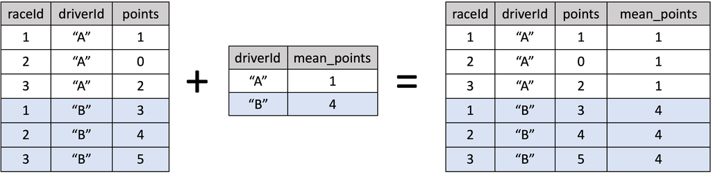

- Let’s see an example. We’ll use the `drivers_agg` data frame we created before and merge it with the original `results` data frame

```python
drivers_agg.round(2)
```

| driverId | mean_points | sd_points | min_points | max_points | count_obs |
| --- | --- | --- | --- | --- | --- |
| 1 | 14.18 | 9.22 | 0.0 | 50.0 | 310 |
| 2 | 1.41 | 2.37 | 0.0 | 15.0 | 184 |
| 3 | 7.74 | 8.67 | 0.0 | 25.0 | 206 |
| 4 | 5.76 | 6.33 | 0.0 | 25.0 | 358 |
| 5 | 0.94 | 1.97 | 0.0 | 10.0 | 112 |
| ... | ... | ... | ... | ... | ... |
| 852 | 1.00 | 2.48 | 0.0 | 12.0 | 44 |
| 853 | 0.00 | 0.00 | 0.0 | 0.0 | 22 |
| 854 | 0.27 | 1.34 | 0.0 | 8.0 | 44 |
| 855 | 0.27 | 0.88 | 0.0 | 4.0 | 22 |
| 856 | 2.00 | NaN | 2.0 | 2.0 | 1 |

855 rows × 5 columns

## Relative statistics within group

- And here is the `results` data frame

```python
results.head()
```

|  | resultId | raceId | driverId | constructorId | number | grid | position | positionText | positionOrder | points | laps | time | milliseconds | fastestLap | rank | fastestLapTime | fastestLapSpeed | statusId |
| --- | --- | --- | --- | --- | --- | --- | --- | --- | --- | --- | --- | --- | --- | --- | --- | --- | --- | --- |
| 0 | 1 | 18 | 1 | 1 | 22 | 1 | 1 | 1 | 1 | 10.0 | 58 | 1:34:50.616 | 5690616 | 39 | 2 | 1:27.452 | 218.300 | 1 |
| 1 | 2 | 18 | 2 | 2 | 3 | 5 | 2 | 2 | 2 | 8.0 | 58 | +5.478 | 5696094 | 41 | 3 | 1:27.739 | 217.586 | 1 |
| 2 | 3 | 18 | 3 | 3 | 7 | 7 | 3 | 3 | 3 | 6.0 | 58 | +8.163 | 5698779 | 41 | 5 | 1:28.090 | 216.719 | 1 |
| 3 | 4 | 18 | 4 | 4 | 5 | 11 | 4 | 4 | 4 | 5.0 | 58 | +17.181 | 5707797 | 58 | 7 | 1:28.603 | 215.464 | 1 |
| 4 | 5 | 18 | 5 | 1 | 23 | 3 | 5 | 5 | 5 | 4.0 | 58 | +18.014 | 5708630 | 43 | 1 | 1:27.418 | 218.385 | 1 |

- Now we can merge the two data frames using the `driverId` column
- Why do we use `on='driverId'`? Because `driverId` is the column that identifies the driver in both data frames

```python
results_merge = pd.merge(results,
                         drivers_agg,
                         on = "driverId",
                         how = "left")
```

- The `how = "left"` argument keeps all rows from the `results` data frame and adds the statistics from `drivers_agg` to it
- The result is a new data frame with the statistics for each driver

## Relative statistics within group

- Let’s see the first few rows of the merged data frame

```python
results_merge.head()
```

|  | resultId | raceId | driverId | constructorId | number | grid | position | positionText | positionOrder | points | ... | fastestLap | rank | fastestLapTime | fastestLapSpeed | statusId | mean_points | sd_points | min_points | max_points | count_obs |
| --- | --- | --- | --- | --- | --- | --- | --- | --- | --- | --- | --- | --- | --- | --- | --- | --- | --- | --- | --- | --- | --- |
| 0 | 1 | 18 | 1 | 1 | 22 | 1 | 1 | 1 | 1 | 10.0 | ... | 39 | 2 | 1:27.452 | 218.300 | 1 | 14.182258 | 9.224098 | 0.0 | 50.0 | 310 |
| 1 | 2 | 18 | 2 | 2 | 3 | 5 | 2 | 2 | 2 | 8.0 | ... | 41 | 3 | 1:27.739 | 217.586 | 1 | 1.407609 | 2.372923 | 0.0 | 15.0 | 184 |
| 2 | 3 | 18 | 3 | 3 | 7 | 7 | 3 | 3 | 3 | 6.0 | ... | 41 | 5 | 1:28.090 | 216.719 | 1 | 7.740291 | 8.672456 | 0.0 | 25.0 | 206 |
| 3 | 4 | 18 | 4 | 4 | 5 | 11 | 4 | 4 | 4 | 5.0 | ... | 58 | 7 | 1:28.603 | 215.464 | 1 | 5.756983 | 6.330721 | 0.0 | 25.0 | 358 |
| 4 | 5 | 18 | 5 | 1 | 23 | 3 | 5 | 5 | 5 | 4.0 | ... | 43 | 1 | 1:27.418 | 218.385 | 1 | 0.937500 | 1.969503 | 0.0 | 10.0 | 112 |

5 rows × 23 columns

- We can see that the new columns `mean_points`, `sd_points`, `min_points`, `max_points`, and `count_obs` were added to the data frame

```python
results_merge.columns
```

```
Index(['resultId', 'raceId', 'driverId', 'constructorId', 'number', 'grid',
       'position', 'positionText', 'positionOrder', 'points', 'laps', 'time',
       'milliseconds', 'fastestLap', 'rank', 'fastestLapTime',
       'fastestLapSpeed', 'statusId', 'mean_points', 'sd_points', 'min_points',
       'max_points', 'count_obs'],
      dtype='object')
```

## Try it yourself! 🤓

- Compute a scatter plot with `points` (y-axis) vs `mean_points` (x-axis)
- Note: This plots tells you how much a driver’s performance on individual races deviates from their overall average
- Appendix 03

## Try it yourself! 🤓

- Merge the `teamrace_agg` data into `results`
- This time use the option: `on = ["raceId","constructorId"]`
- Appendix 04

## Appendix 01

- Let’s start by counting the number of rows in the dataset

```python
len(results)
```

```
25840
```

- Now let’s count the number of unique values for the columns `resultId`, `raceId`, and `driverId`

```python
results.resultId.nunique()
```

```
25840
```

```python
results.raceId.nunique()
```

```
1079
```

```python
results.driverId.nunique()
```

```
855
```

## Appendix 01

- You could also used `value_counts()` to get the same information

```python
results.resultId.value_counts()
```

```
resultId
1        1
17224    1
17234    1
17233    1
17232    1
        ..
8611     1
8610     1
8609     1
8608     1
25845    1
Name: count, Length: 25840, dtype: int64
```

```python
results.raceId.value_counts()
```

```
raceId
800    55
809    47
371    39
359    39
366    39
       ..
657    14
668    14
827    13
660    13
765    10
Name: count, Length: 1079, dtype: int64
```

```python
results.driverId.value_counts()
```

```
driverId
4      358
8      352
22     326
1      310
18     309
      ...
545      1
331      1
492      1
546      1
856      1
Name: count, Length: 855, dtype: int64
```

- This function returns the number of times each unique value appears in the column

Back to exercise

## Appendix 02

- Let’s start by grouping the data by `constructorId` and computing the average number of `points`

```python
team_agg = (results.groupby("constructorId")
                   .agg(mean_points = ('points','mean')))
```

- Now let’s sort the data by `mean_points` in descending order
- We can use the `sort_values()` method

```python
team_agg.sort_values("mean_points", ascending = False).round(2)
```

| constructorId | mean_points |
| --- | --- |
| 131 | 12.36 |
| 9 | 9.12 |
| 23 | 5.06 |
| 208 | 4.58 |
| 6 | 4.32 |
| ... | ... |
| 76 | 0.00 |
| 77 | 0.00 |
| 78 | 0.00 |
| 130 | 0.00 |
| 112 | 0.00 |

210 rows × 1 columns

Back to exercise

## Appendix 03

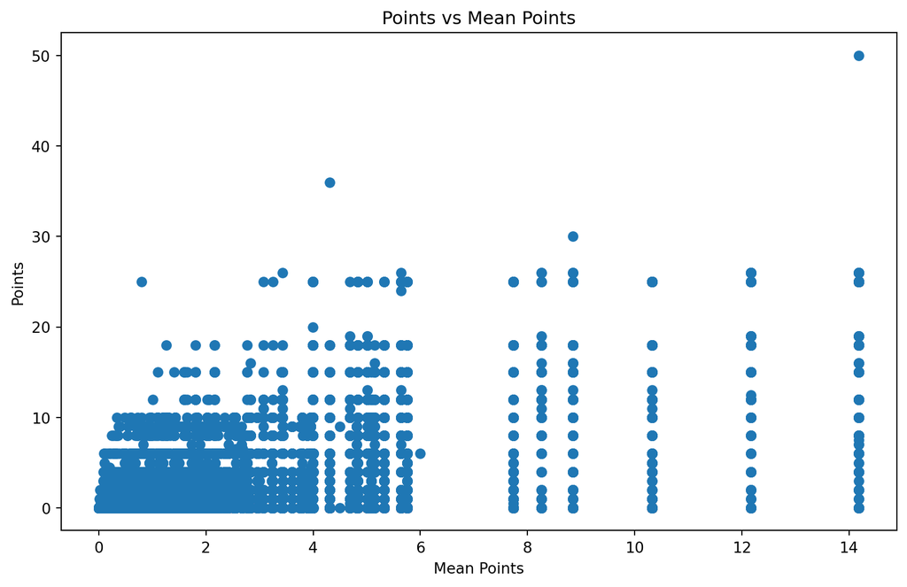

```python
plt.figure(figsize=(10,6))
plt.scatter(results_merge["mean_points"], results_merge["points"])
plt.xlabel("Mean Points")
plt.ylabel("Points")
plt.title("Points vs Mean Points")
plt.show()
```

- This plots tells you how much a driver’s performance on individual races deviates from their overall average

Back to exercise

## Appendix 04

- Let’s merge the `teamrace_agg` data into `results`
- This time use the option: `on = ["raceId","constructorId"]`
- Since we filtered the data before (`raceId >= 500`), we will see some missing cases in the merged data frame

```python
results_merge = pd.merge(results,
                         teamrace_agg,
                         on = ["raceId","constructorId"],
                         how = "left")
results_merge.round(2)
```

|  | resultId | raceId | driverId | constructorId | number | grid | position | positionText | positionOrder | points | ... | fastestLap | rank | fastestLapTime | fastestLapSpeed | statusId | mean_points | sd_points | min_points | max_points | count_obs |
| --- | --- | --- | --- | --- | --- | --- | --- | --- | --- | --- | --- | --- | --- | --- | --- | --- | --- | --- | --- | --- | --- |
| 0 | 1 | 18 | 1 | 1 | 22 | 1 | 1 | 1 | 1 | 10.0 | ... | 39 | 2 | 1:27.452 | 218.300 | 1 | NaN | NaN | NaN | NaN | NaN |
| 1 | 2 | 18 | 2 | 2 | 3 | 5 | 2 | 2 | 2 | 8.0 | ... | 41 | 3 | 1:27.739 | 217.586 | 1 | NaN | NaN | NaN | NaN | NaN |
| 2 | 3 | 18 | 3 | 3 | 7 | 7 | 3 | 3 | 3 | 6.0 | ... | 41 | 5 | 1:28.090 | 216.719 | 1 | NaN | NaN | NaN | NaN | NaN |
| 3 | 4 | 18 | 4 | 4 | 5 | 11 | 4 | 4 | 4 | 5.0 | ... | 58 | 7 | 1:28.603 | 215.464 | 1 | NaN | NaN | NaN | NaN | NaN |
| 4 | 5 | 18 | 5 | 1 | 23 | 3 | 5 | 5 | 5 | 4.0 | ... | 43 | 1 | 1:27.418 | 218.385 | 1 | NaN | NaN | NaN | NaN | NaN |
| ... | ... | ... | ... | ... | ... | ... | ... | ... | ... | ... | ... | ... | ... | ... | ... | ... | ... | ... | ... | ... | ... |
| 25835 | 25841 | 1096 | 854 | 210 | 47 | 12 | 16 | 16 | 16 | 0.0 | ... | 39 | 12 | 1:29.833 | 211.632 | 11 | 0.0 | 0.00 | 0.0 | 0.0 | 2.0 |
| 25836 | 25842 | 1096 | 825 | 210 | 20 | 16 | 17 | 17 | 17 | 0.0 | ... | 40 | 20 | 1:31.158 | 208.556 | 11 | 0.0 | 0.00 | 0.0 | 0.0 | 2.0 |
| 25837 | 25843 | 1096 | 1 | 131 | 44 | 5 | 18 | 18 | 18 | 0.0 | ... | 42 | 11 | 1:29.788 | 211.738 | 9 | 5.0 | 7.07 | 0.0 | 10.0 | 2.0 |
| 25838 | 25844 | 1096 | 849 | 3 | 6 | 20 | 19 | 19 | 19 | 0.0 | ... | 45 | 14 | 1:30.309 | 210.517 | 130 | 0.0 | 0.00 | 0.0 | 0.0 | 2.0 |
| 25839 | 25845 | 1096 | 4 | 214 | 14 | 10 | \N | R | 20 | 0.0 | ... | 24 | 17 | 1:30.579 | 209.889 | 47 | 3.0 | 4.24 | 0.0 | 6.0 | 2.0 |

25840 rows × 23 columns

## Appendix 04

- We can remove the missing cases using the `dropna()` method

```python
results_merge = pd.merge(results,
                         teamrace_agg,
                         on = ["raceId","constructorId"],
                         how = "left")
results_merge.round(2).dropna()
```

|  | resultId | raceId | driverId | constructorId | number | grid | position | positionText | positionOrder | points | ... | fastestLap | rank | fastestLapTime | fastestLapSpeed | statusId | mean_points | sd_points | min_points | max_points | count_obs |
| --- | --- | --- | --- | --- | --- | --- | --- | --- | --- | --- | --- | --- | --- | --- | --- | --- | --- | --- | --- | --- | --- |
| 12049 | 12050 | 500 | 163 | 4 | 16 | 2 | 1 | 1 | 1 | 9.0 | ... | \N | \N | \N | \N | 1 | 4.5 | 6.36 | 0.0 | 9.0 | 2.0 |
| 12050 | 12051 | 500 | 172 | 27 | 26 | 4 | 2 | 2 | 2 | 6.0 | ... | \N | \N | \N | \N | 1 | 5.0 | 1.41 | 4.0 | 6.0 | 2.0 |
| 12051 | 12052 | 500 | 202 | 27 | 25 | 5 | 3 | 3 | 3 | 4.0 | ... | \N | \N | \N | \N | 1 | 5.0 | 1.41 | 4.0 | 6.0 | 2.0 |
| 12052 | 12053 | 500 | 137 | 34 | 5 | 3 | 4 | 4 | 4 | 3.0 | ... | \N | \N | \N | \N | 1 | 1.5 | 2.12 | 0.0 | 3.0 | 2.0 |
| 12053 | 12054 | 500 | 199 | 3 | 28 | 6 | 5 | 5 | 5 | 2.0 | ... | \N | \N | \N | \N | 11 | 1.0 | 1.41 | 0.0 | 2.0 | 2.0 |
| ... | ... | ... | ... | ... | ... | ... | ... | ... | ... | ... | ... | ... | ... | ... | ... | ... | ... | ... | ... | ... | ... |
| 25835 | 25841 | 1096 | 854 | 210 | 47 | 12 | 16 | 16 | 16 | 0.0 | ... | 39 | 12 | 1:29.833 | 211.632 | 11 | 0.0 | 0.00 | 0.0 | 0.0 | 2.0 |
| 25836 | 25842 | 1096 | 825 | 210 | 20 | 16 | 17 | 17 | 17 | 0.0 | ... | 40 | 20 | 1:31.158 | 208.556 | 11 | 0.0 | 0.00 | 0.0 | 0.0 | 2.0 |
| 25837 | 25843 | 1096 | 1 | 131 | 44 | 5 | 18 | 18 | 18 | 0.0 | ... | 42 | 11 | 1:29.788 | 211.738 | 9 | 5.0 | 7.07 | 0.0 | 10.0 | 2.0 |
| 25838 | 25844 | 1096 | 849 | 3 | 6 | 20 | 19 | 19 | 19 | 0.0 | ... | 45 | 14 | 1:30.309 | 210.517 | 130 | 0.0 | 0.00 | 0.0 | 0.0 | 2.0 |
| 25839 | 25845 | 1096 | 4 | 214 | 14 | 10 | \N | R | 20 | 0.0 | ... | 24 | 17 | 1:30.579 | 209.889 | 47 | 3.0 | 4.24 | 0.0 | 6.0 | 2.0 |

12267 rows × 23 columns

Back to exercise

[Aggregating Data](https://raw.githack.com/danilofreire/qtm151/main/lectures/lecture-15/15-aggregating-data.html)